# Course Project Machine Learning

Lei

23 August 2017

## Background

In this project, a machine learning model was generated using data from accelerometers on the belt, forearm, arm, and dumbell of 6 participants, in order to predict the class of movements of the test dataset. This dataset is freely available under the “Creative Commons license (CC BY-SA) license from the website here: http://groupware.les.inf.puc-rio.br/har (Weight Lifting Exercise Dataset).

## Loading datasets

First, the data was downloaded from the course links, and loaded into the Rstudio workspace.

```r
#change wd:
setwd("~/Rstudio")
#download the two files to wd:
traindataUrl <- "https://d396qusza40orc.cloudfront.net/predmachlearn/pml-training.csv"
#download.file(url=traindataUrl, destfile="~/Rstudio/training.csv")

testdataUrl <- "https://d396qusza40orc.cloudfront.net/predmachlearn/pml-testing.csv"
#download.file(url=testdataUrl, destfile="test.csv")

#load datasets:
training <- read.csv(url(traindataUrl), na.strings=c("NA","#DIV/0!",""))
testing <- read.csv(url(testdataUrl), na.strings=c("NA","#DIV/0!",""))
```

For model building using machine learning, we first ignore the test dataset and make some exploratory analysis on the training dataset. Note that I out-commanded the summary function as the output is much too long for this report.

```r
dim(training)
```

```
## [1] 19622   160
```

```r
#summary(training)
#names(training)
unique(training$classe)
```

```
## [1] A B C D E
## Levels: A B C D E
```

For the sake of cross validation of the model that will be generated, we first partitioned the training dataset into two parts: inTrain, and the rest:

```r
library(caret) # this command load also the packages lattice and ggplot2.
inTrain <- createDataPartition(training$classe, p=0.6, list = F)
myTrain <- training[inTrain, ]
myTest <- training[-inTrain, ]
dim(myTrain)
```

```
## [1] 11776   160
```

```r
dim(myTest)
```

```
## [1] 7846  160
```

```r
percent <- paste(round(100*dim(myTrain)[[1]]/(dim(myTrain)[[1]] + dim(myTest)[[1]]), 2), "%", sep="")
```

As shown above, a short check of the dataset dimension shows that 60.01% of the data points were assigned to the current training set.

## Cleaning data

#### Step 1: Remove variables with nearly zero variance (both mean and sd are zero)

```r
zeros <- nearZeroVar(myTrain)
myTrain <- myTrain[, -zeros]
myTest <- myTest[, -zeros]
testing <- testing[, -zeros]
```

By this means, 30 variables were removed.

#### Step 2: Remove variables that are NA in more than 95% of the cases:

```r
mostlyNA <- sapply(myTrain, function(x) mean(is.na(x))) > 0.95
myTrain <- myTrain[, mostlyNA==F]
myTest <- myTest[, mostlyNA==F]
testing <- testing[, mostlyNA==F]
```

#### Step 3: Remove the first columns

Moreover, we remove the first five variables that contain meta data of the participants, while do not have predictive values.

```r
myTrain <- myTrain[, -(1:5)]
myTest <- myTest[, -(1:5)]
testing <- testing[, -(1:5)]
```

## Model building 1 - Decision Tree

The principle of Decision tree appears intuitive to me due to its step-by-step manor. Therefore I first try out the Decision tree machine learning approach:

```r
library(rpart)

Mod_1 <- rpart(classe ~ ., data=myTrain, method="class")
#fancyRpartPlot(modFitA1)
predict_1 <- predict(Mod_1, myTest, type = "class")
tree <- confusionMatrix(predict_1, myTest$classe)
tree
```

```
## Confusion Matrix and Statistics
##
##           Reference
## Prediction    A    B    C    D    E
##          A 2009  272   48   81   62
##          B  145 1012  218  191  193
##          C   24   91  964  112   63
##          D   45   88   81  822  153
##          E    9   55   57   80  971
##
## Overall Statistics
##
##                Accuracy : 0.7364
##                  95% CI : (0.7265, 0.7461)
##     No Information Rate : 0.2845
##     P-Value [Acc > NIR] : < 2.2e-16
##
##                   Kappa : 0.665
##  Mcnemar's Test P-Value : < 2.2e-16
##
## Statistics by Class:
##
##                      Class: A Class: B Class: C Class: D Class: E
## Sensitivity            0.9001   0.6667   0.7047   0.6392   0.6734
## Specificity            0.9175   0.8820   0.9552   0.9441   0.9686
## Pos Pred Value         0.8127   0.5753   0.7687   0.6913   0.8285
## Neg Pred Value         0.9585   0.9169   0.9387   0.9303   0.9294
## Prevalence             0.2845   0.1935   0.1744   0.1639   0.1838
## Detection Rate         0.2561   0.1290   0.1229   0.1048   0.1238
## Detection Prevalence   0.3151   0.2242   0.1598   0.1515   0.1494
## Balanced Accuracy      0.9088   0.7743   0.8300   0.7916   0.8210
```

```r
#plot(Mod_1)
```

Now let’s predict the myTest data using this tree model, while making some decision tree figure:

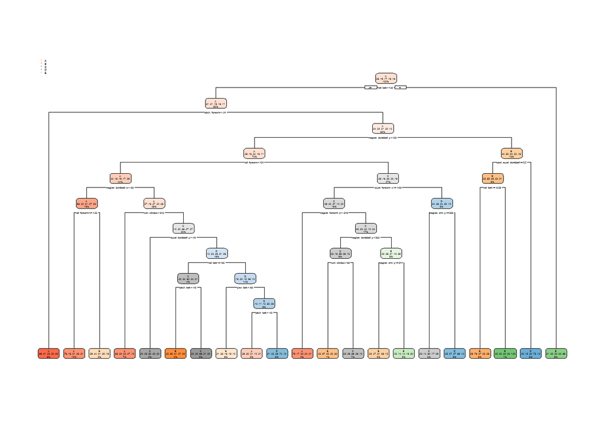

```r
#install.packages("rpart.plot")
library(rpart.plot)
#library(RColorBrewer)
#library(rattle)

rpart.plot(Mod_1)
```

In the following we check the result of the cross-validation on myTest:

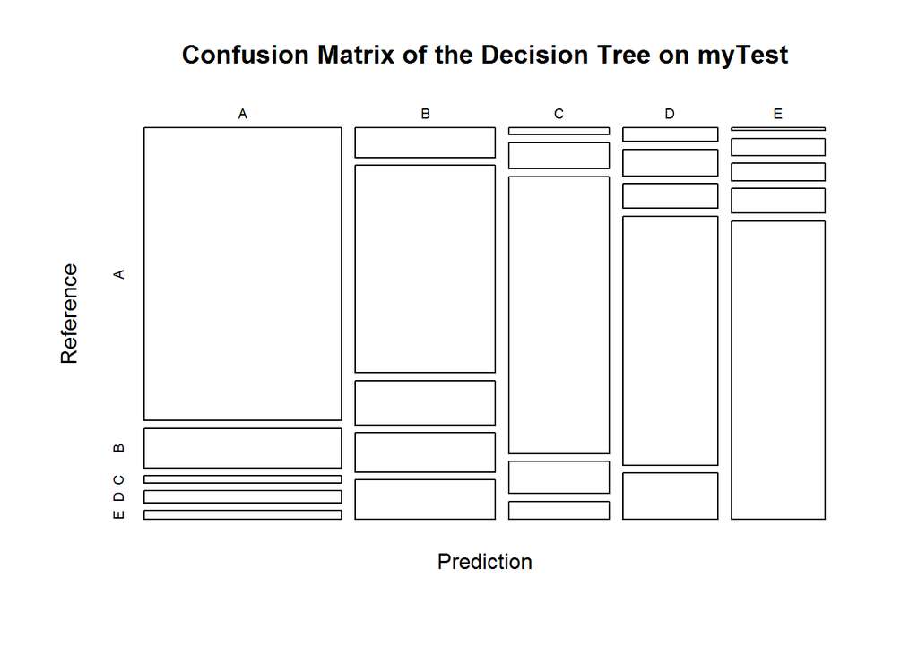

```r
plot(tree$table, col=tree$byClass, main="Confusion Matrix of the Decision Tree on myTest")
```

The prediction worked in part, as can be seen by the biggest diagonal rectangulars in the confusion matrix plot above. However, the sensitivity of the model is not that high.

## Model building 2 - Random Forest

Before proceeding to the final prediction on the test dataset, let’s try out the random forest model:

```r
library(randomForest)
Mod_2 <- randomForest(classe ~ ., data=myTrain)
predict_2 <- predict(Mod_2, myTest, type = "class")
forest <- confusionMatrix(predict_2, myTest$classe)
forest
```

```
## Confusion Matrix and Statistics
##
##           Reference
## Prediction    A    B    C    D    E
##          A 2231    7    0    0    0
##          B    1 1511   11    0    0
##          C    0    0 1353   11    0
##          D    0    0    4 1275    6
##          E    0    0    0    0 1436
##
## Overall Statistics
##
##                Accuracy : 0.9949
##                  95% CI : (0.9931, 0.9964)
##     No Information Rate : 0.2845
##     P-Value [Acc > NIR] : < 2.2e-16
##
##                   Kappa : 0.9936
##  Mcnemar's Test P-Value : NA
##
## Statistics by Class:
##
##                      Class: A Class: B Class: C Class: D Class: E
## Sensitivity            0.9996   0.9954   0.9890   0.9914   0.9958
## Specificity            0.9988   0.9981   0.9983   0.9985   1.0000
## Pos Pred Value         0.9969   0.9921   0.9919   0.9922   1.0000
## Neg Pred Value         0.9998   0.9989   0.9977   0.9983   0.9991
## Prevalence             0.2845   0.1935   0.1744   0.1639   0.1838
## Detection Rate         0.2843   0.1926   0.1724   0.1625   0.1830
## Detection Prevalence   0.2852   0.1941   0.1738   0.1638   0.1830
## Balanced Accuracy      0.9992   0.9967   0.9937   0.9950   0.9979
```

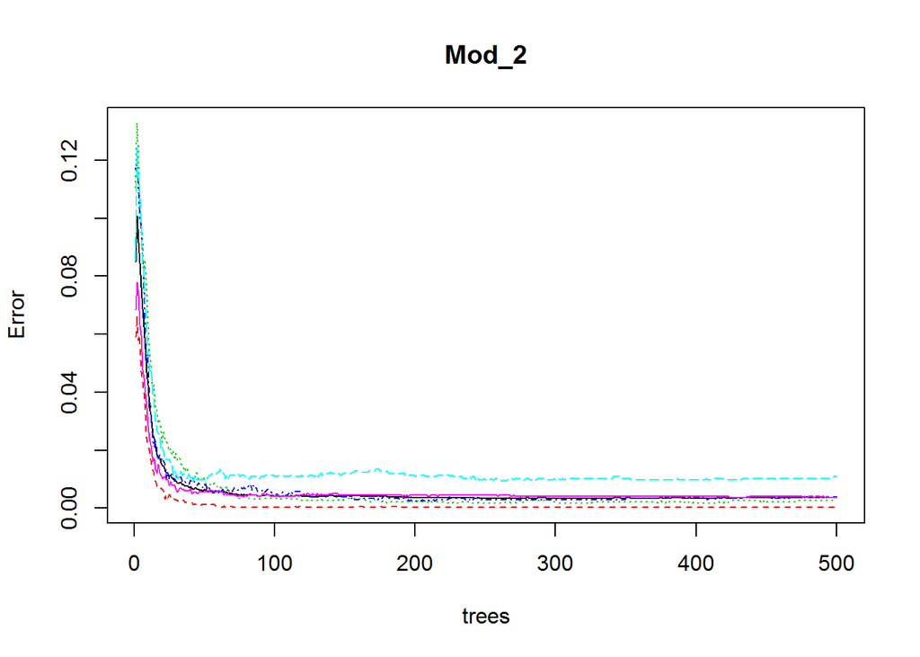

```r
plot(Mod_2)
```

This time, both the sensitivity and specificity are really high, even 100% when the cross validation dataset is concerned. Therefore, we will conduct our final prediction using the random forest model:

```r
#dim(myTrain)
#dim(myTest)
#dim(testing)
#names(myTest)
#names(testing)

predict_final <- predict(Mod_2, testing, type = "class")
predict_final
```

```
##  1  2  3  4  5  6  7  8  9 10 11 12 13 14 15 16 17 18 19 20
##  B  A  B  A  A  E  D  B  A  A  B  C  B  A  E  E  A  B  B  B
## Levels: A B C D E
```

## Conclusive notes

Amazingly, all 20 cases have been predicted correctly according to my quiz results! This supports a high prediction power of machine learning approaches.

Finally, I would like to acknowledge the following authors that provided the data: Velloso, E.; Bulling, A.; Gellersen, H.; Ugulino, W.; Fuks, H. Qualitative Activity Recognition of Weight Lifting Exercises. Proceedings of 4th International Conference in Cooperation with SIGCHI (Augmented Human ’13) . Stuttgart, Germany: ACM SIGCHI, 2013.